# **Song Popularity Analysis**

Darian Tocci and Marissa Vagnoni

Link to Our Website: https://dartocc.github.io/

# **Project Goals**

**Collaboration Plan:** Aside from breaks and traveling that will require zoom meetings, we will mainly be working on this project in person about 1-2 times a week using a shared google colab and pushing our changes to a shared GitHub respository. Additionally, we will communicate frequently over text with any brief ideas or concerns that need to be addressed in the moment. Lastly, we have created a progress timeline based on the rubric from our syllabus to ensure we are staying on track with each project milestone.

**Research Questions**

- How do musical elements correlate with track popularity?
- Do recent songs differ from older, more classic music in ways that might explain their streaming success?
- Which artists consistently dominate Spotify playlists, and what common traits do their songs share?

# **Milestone 1: Data Tidying for Song Popularity Dataset**

This dataset is fairly tidy as is. There are a few alterations and data table combinations we could make to aid in analyzation.

```python
from google.colab import drive
drive.mount('/content/drive')
import pandas as pd
import matplotlib.pyplot as plt
import numpy as np
import io

file_path_song_data = '/content/drive/MyDrive/song_data.csv'
# Read the CSV
df_song_data = pd.read_csv(file_path_song_data)
```

```python
df_song_data.dtypes
```

|  | 0 |
| --- | --- |
| song_name | object |
| song_popularity | int64 |
| song_duration_ms | int64 |
| acousticness | float64 |
| danceability | float64 |
| energy | float64 |
| instrumentalness | float64 |
| key | int64 |
| liveness | float64 |
| loudness | float64 |
| audio_mode | int64 |
| speechiness | float64 |
| tempo | float64 |
| time_signature | int64 |
| audio_valence | float64 |

**dtype:** object

All columns are assigned the correct type besides audio_mode. This should be assigned as an object as it is categorical data.

Additionally, we will assign a string to each numerical label to clarify the meanings of these values. 1 represents a song in major and 0 represents a song in minor.

```python
df_song_data['audio_mode'] = df_song_data['audio_mode'].map({1: 'major', 0: 'minor'})
df_song_data['audio_mode'] = df_song_data['audio_mode'].astype(str)
```

**Table 1: Basic Musical Data**

This first table groups together basic musical elements that pertain to the structural attributes of each song.

```python
song_basic_data = df_song_data[['song_name', 'song_duration_ms', 'key', 'audio_mode', 'tempo', 'time_signature']].copy()
song_basic_data.head()
```

|  | song_name | song_duration_ms | key | audio_mode | tempo | time_signature |
| --- | --- | --- | --- | --- | --- | --- |
| 0 | Boulevard of Broken Dreams | 262333 | 8 | major | 167.060 | 4 |
| 1 | In The End | 216933 | 3 | minor | 105.256 | 4 |
| 2 | Seven Nation Army | 231733 | 0 | major | 123.881 | 4 |
| 3 | By The Way | 216933 | 0 | major | 122.444 | 4 |
| 4 | How You Remind Me | 223826 | 10 | major | 172.011 | 4 |

**Table 2: Popularity**

Tracks how well each song performs. A key aspect of song popularity is that it is not being used as a ranking. The popularity value given to each song is a score given to each song based on listener engagement from a streaming service.

```python
popularity_table = df_song_data[['song_name', 'song_popularity']].copy()
popularity_table.head()
```

|  | song_name | song_popularity |
| --- | --- | --- |
| 0 | Boulevard of Broken Dreams | 73 |
| 1 | In The End | 66 |
| 2 | Seven Nation Army | 76 |
| 3 | By The Way | 74 |
| 4 | How You Remind Me | 56 |

**Table 3: Audio Features**

Descriptive variables from an audio analysis.

```python
audio_features = df_song_data[['song_name', 'acousticness', 'danceability', 'energy',
                     'instrumentalness', 'liveness', 'loudness', 'speechiness', 'audio_valence']].copy()
audio_features.head()
```

|  | song_name | acousticness | danceability | energy | instrumentalness | liveness | loudness | speechiness | audio_valence |
| --- | --- | --- | --- | --- | --- | --- | --- | --- | --- |
| 0 | Boulevard of Broken Dreams | 0.005520 | 0.496 | 0.682 | 0.000029 | 0.0589 | -4.095 | 0.0294 | 0.474 |
| 1 | In The End | 0.010300 | 0.542 | 0.853 | 0.000000 | 0.1080 | -6.407 | 0.0498 | 0.370 |
| 2 | Seven Nation Army | 0.008170 | 0.737 | 0.463 | 0.447000 | 0.2550 | -7.828 | 0.0792 | 0.324 |
| 3 | By The Way | 0.026400 | 0.451 | 0.970 | 0.003550 | 0.1020 | -4.938 | 0.1070 | 0.198 |
| 4 | How You Remind Me | 0.000954 | 0.447 | 0.766 | 0.000000 | 0.1130 | -5.065 | 0.0313 | 0.574 |

# **Exploratory Data Analysis**

**Most Popular Vs. Least Popular**

```python
# Filtering songs with popularity 100 and 0
most_pop = df_song_data[df_song_data['song_popularity'] == 100]
least_pop = df_song_data[df_song_data['song_popularity'] == 0]

# Finding mean for each group
most_pop_avg = most_pop.mean(numeric_only=True)
least_pop_avg = least_pop.mean(numeric_only=True)

# Combining into one DataFrame for comparison
popularity_comparison = pd.DataFrame({
    'most_popular_avgs': most_pop_avg,
    'least_popular_avgs': least_pop_avg
})

print(popularity_comparison)
```

```
                  most_popular_avgs  least_popular_avgs
song_popularity            100.0000            0.000000
song_duration_ms        214289.0000       225549.658088
acousticness                 0.1910            0.205888
danceability                 0.6870            0.646309
energy                       0.7920            0.661555
instrumentalness             0.0000            0.128275
key                          5.0000            5.753676
liveness                     0.1670            0.188359
loudness                    -2.7490           -7.283570
speechiness                  0.0452            0.141242
tempo                      100.0150          125.781934
time_signature               4.0000            3.959559
audio_valence                0.6710            0.539374
```

This comparison can be used to find the major differences between popular and non-popular songs. This data can get us closer to our conclusion of which musical elements aid in a song's popularity. Some takeaways from the data above are that a louder track tends to be more popular and that a shorter song tends to be more popular. Elements such as key, time signature, and danceability appear to have very close averages and could potentially be considered void for the impact on a song's popularity. However, more data will need to be observed before this conclusion is met.

**Popularity Comparison Between Major and Minor Songs**

```python
summary = df_song_data.groupby('audio_mode').agg(
    count=('song_popularity', 'size'),
    avg_popularity=('song_popularity', 'mean')
)
print(summary)
```

```
            count  avg_popularity
audio_mode
major       11831       52.908123
minor        7004       53.133352
```

Songs in major typically have a happier, lighter feel that can be a factor in an upbeat mood or motivation. Songs in minor are typically sad and can aid in a calm, relaxed, or melancholy mood. This element can be important to see if happy or sad songs are typically more popular. From the data above we can see that there are a significantly higher amount of songs in major compared to minor, so this summarization may not be the most beneficial to use. However, when looking at the average popularity between the two, we can see that they are extremely similar. This may indicate that a song being in major or minor does not necessarily impact its popularity.

**Correlation Between Danceability and Popularity**

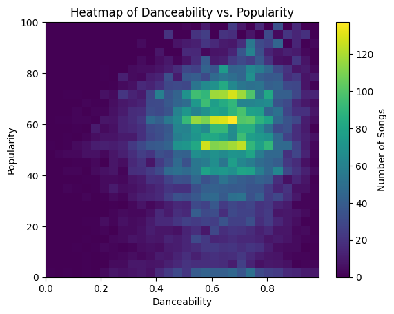

```python
plt.hist2d(df_song_data['danceability'], df_song_data['song_popularity'], bins=[30, 30], cmap='viridis')
plt.colorbar(label='Number of Songs')
plt.xlabel('Danceability')
plt.ylabel('Popularity')
plt.title('Heatmap of Danceability vs. Popularity')
```

The heat map above reflects that there are a high volume of songs that are more danceable (around 0.5-0.7) and they are scaled between 40-80 on the popularity scale. This may indicate that songs with a danceable attribute are moderately to highly popular amongst listeners.

**Popularity by Tempo Range**

```python
#create simple tempo bins
tempo_bins = [0, 80, 120, 160, 300]  # slow, medium, fast, very fast
tempo_labels = ['Slow', 'Medium', 'Fast', 'Very Fast']
df_song_data['tempo_range'] = pd.cut(df_song_data['tempo'], bins=tempo_bins, labels=tempo_labels, include_lowest=True)

#group by tempo range
summary_tempo = df_song_data.groupby('tempo_range').agg(
    count=('song_popularity', 'size'),
    avg_popularity=('song_popularity', 'mean')
)

print(summary_tempo)
```

```
             count  avg_popularity
tempo_range
Slow          1087       51.786569
Medium        8266       53.771594
Fast          7427       52.537768
Very Fast     2055       52.134307
```

We divided up the songs into 4 different tempos: Slow, Medium, Fast, and Very Fast. The results show that medium-tempo songs are both the most common and have the highest average popularity. Slow and very fast songs are less frequent and slightly less popular on average. This show us that that songs with a more moderate tempo tend to be more popular.

# **Milestone 2: Data Tidying for Prediction of Music Genre Dataset**

This dataset is quite similar to the previous, however, it includes older songs and a few extra musical elements that the previous set did not include. This could be useful in building our future model if we use some of this data and combine it with data of the previous set.

This is a fairly tidy dataset, however there are some issues surrounding data types and ways to organize the tables into different datasets based on groupings.

```python
file_path_music_genre = '/content/drive/MyDrive/music_genre.csv'
# Read the CSV
df_music_genre = pd.read_csv(file_path_music_genre)
```

```python
from google.colab import drive
drive.mount('/content/drive')
```

Right now, pandas is assuming tempo is an object when it should really be a float. We can fix this by correcting the data type assignment of tempo.

```python
df_music_genre["tempo"] = pd.to_numeric(df_music_genre["tempo"], errors = "coerce")
```

```python
df_music_genre.dtypes
```

|  | 0 |
| --- | --- |
| instance_id | float64 |
| artist_name | object |
| track_name | object |
| popularity | float64 |
| acousticness | float64 |
| danceability | float64 |
| duration_ms | float64 |
| energy | float64 |
| instrumentalness | float64 |
| key | object |
| liveness | float64 |
| loudness | float64 |
| mode | object |
| speechiness | float64 |
| tempo | float64 |
| obtained_date | object |
| valence | float64 |
| music_genre | object |

**dtype:** object

Next, obtained_date is not a relevant variable to the overall goal of the project so that column can be dropped.

```python
df_music_genre.drop("obtained_date", axis = 1, inplace = True)
```

Next, we want to change the column headings to match our previously used dataset. This can be valuable for merging the datasets if they have songs in common.

```python
df_music_genre.rename(columns = {"track_name": "song_name", "popularity": "song_popularity", "duration_ms": "song_duration_ms", "mode": "audio_mode", "valence": "audio_valence"}, inplace = True)
```

```python
df_music_genre.head()
```

|  | instance_id | artist_name | song_name | song_popularity | acousticness | danceability | song_duration_ms | energy | instrumentalness | key | liveness | loudness | audio_mode | speechiness | tempo | audio_valence | music_genre |
| --- | --- | --- | --- | --- | --- | --- | --- | --- | --- | --- | --- | --- | --- | --- | --- | --- | --- |
| 0 | 32894.0 | Röyksopp | Röyksopp's Night Out | 27.0 | 0.00468 | 0.652 | -1.0 | 0.941 | 0.79200 | A# | 0.115 | -5.201 | Minor | 0.0748 | 100.889 | 0.759 | Electronic |
| 1 | 46652.0 | Thievery Corporation | The Shining Path | 31.0 | 0.01270 | 0.622 | 218293.0 | 0.890 | 0.95000 | D | 0.124 | -7.043 | Minor | 0.0300 | 115.002 | 0.531 | Electronic |
| 2 | 30097.0 | Dillon Francis | Hurricane | 28.0 | 0.00306 | 0.620 | 215613.0 | 0.755 | 0.01180 | G# | 0.534 | -4.617 | Major | 0.0345 | 127.994 | 0.333 | Electronic |
| 3 | 62177.0 | Dubloadz | Nitro | 34.0 | 0.02540 | 0.774 | 166875.0 | 0.700 | 0.00253 | C# | 0.157 | -4.498 | Major | 0.2390 | 128.014 | 0.270 | Electronic |
| 4 | 24907.0 | What So Not | Divide & Conquer | 32.0 | 0.00465 | 0.638 | 222369.0 | 0.587 | 0.90900 | F# | 0.157 | -6.266 | Major | 0.0413 | 145.036 | 0.323 | Electronic |

Next, we are going to group the variables into smaller datatables based on different groupings.

**Table 1: Track Identifiers**

This table contains information based on identifying atributes to each song.

```python
song_identifying_data = df_music_genre[['instance_id', 'artist_name', 'song_name', 'music_genre']].copy()
song_identifying_data.head()
```

|  | instance_id | artist_name | song_name | music_genre |
| --- | --- | --- | --- | --- |
| 0 | 32894.0 | Röyksopp | Röyksopp's Night Out | Electronic |
| 1 | 46652.0 | Thievery Corporation | The Shining Path | Electronic |
| 2 | 30097.0 | Dillon Francis | Hurricane | Electronic |
| 3 | 62177.0 | Dubloadz | Nitro | Electronic |
| 4 | 24907.0 | What So Not | Divide & Conquer | Electronic |

**Table 2: Popularity**

This datatable just contains the populairty metrics for each song.

```python
song_popularity_data = df_music_genre[['song_name', 'song_popularity']].copy()
song_popularity_data.head()
```

|  | song_name | song_popularity |
| --- | --- | --- |
| 0 | Röyksopp's Night Out | 27.0 |
| 1 | The Shining Path | 31.0 |
| 2 | Hurricane | 28.0 |
| 3 | Nitro | 34.0 |
| 4 | Divide & Conquer | 32.0 |

**Table 3: Musical Structure**

This datatable contains information surrounding the musical structure of each song. This can be used to see if a particular musical style effects populairty.

```python
song_musical_structure = df_music_genre[['song_duration_ms', 'tempo', 'key', 'audio_mode']].copy()
song_musical_structure.head()
```

|  | song_duration_ms | tempo | key | audio_mode |
| --- | --- | --- | --- | --- |
| 0 | -1.0 | 100.889 | A# | Minor |
| 1 | 218293.0 | 115.002 | D | Minor |
| 2 | 215613.0 | 127.994 | G# | Major |
| 3 | 166875.0 | 128.014 | C# | Major |
| 4 | 222369.0 | 145.036 | F# | Major |

**Table 4: Audio Features**

This table just contains attributes surrounding the audio features for each song. This can be used to see if a particular audio type effects song popularity.

```python
song_audio_features = df_music_genre[['acousticness', 'danceability', 'energy', 'instrumentalness', 'liveness', 'loudness', 'speechiness', 'audio_valence']].copy()
song_audio_features.head()
```

|  | acousticness | danceability | energy | instrumentalness | liveness | loudness | speechiness | audio_valence |
| --- | --- | --- | --- | --- | --- | --- | --- | --- |
| 0 | 0.00468 | 0.652 | 0.941 | 0.79200 | 0.115 | -5.201 | 0.0748 | 0.759 |
| 1 | 0.01270 | 0.622 | 0.890 | 0.95000 | 0.124 | -7.043 | 0.0300 | 0.531 |
| 2 | 0.00306 | 0.620 | 0.755 | 0.01180 | 0.534 | -4.617 | 0.0345 | 0.333 |
| 3 | 0.02540 | 0.774 | 0.700 | 0.00253 | 0.157 | -4.498 | 0.2390 | 0.270 |
| 4 | 0.00465 | 0.638 | 0.587 | 0.90900 | 0.157 | -6.266 | 0.0413 | 0.323 |

Next, we will concat the music genre data frame and this data frame. This can be helpful in future models where we need more data.

```python
ultimate_song_data = pd.concat([df_song_data, df_music_genre], axis=0, ignore_index=True)
ultimate_song_data.head()
```

|  | song_name | song_popularity | song_duration_ms | acousticness | danceability | energy | instrumentalness | key | liveness | loudness | audio_mode | speechiness | tempo | time_signature | audio_valence | tempo_range | instance_id | artist_name | music_genre |
| --- | --- | --- | --- | --- | --- | --- | --- | --- | --- | --- | --- | --- | --- | --- | --- | --- | --- | --- | --- |
| 0 | Boulevard of Broken Dreams | 73.0 | 262333.0 | 0.005520 | 0.496 | 0.682 | 0.000029 | 8 | 0.0589 | -4.095 | major | 0.0294 | 167.060 | 4.0 | 0.474 | Very Fast | NaN | NaN | NaN |
| 1 | In The End | 66.0 | 216933.0 | 0.010300 | 0.542 | 0.853 | 0.000000 | 3 | 0.1080 | -6.407 | minor | 0.0498 | 105.256 | 4.0 | 0.370 | Medium | NaN | NaN | NaN |
| 2 | Seven Nation Army | 76.0 | 231733.0 | 0.008170 | 0.737 | 0.463 | 0.447000 | 0 | 0.2550 | -7.828 | major | 0.0792 | 123.881 | 4.0 | 0.324 | Fast | NaN | NaN | NaN |
| 3 | By The Way | 74.0 | 216933.0 | 0.026400 | 0.451 | 0.970 | 0.003550 | 0 | 0.1020 | -4.938 | major | 0.1070 | 122.444 | 4.0 | 0.198 | Fast | NaN | NaN | NaN |
| 4 | How You Remind Me | 56.0 | 223826.0 | 0.000954 | 0.447 | 0.766 | 0.000000 | 10 | 0.1130 | -5.065 | major | 0.0313 | 172.011 | 4.0 | 0.574 | Very Fast | NaN | NaN | NaN |

# **Exploratory Data Analysis**

Similar to the previous dataset, we will see how the averages for each variable differ between the most popular songs and the least popular.

```python
# Filtering songs with popularity 100 and 0
most_pop = df_music_genre[df_music_genre['song_popularity'] == 99]
least_pop = df_music_genre[df_music_genre['song_popularity'] == 0]

# Finding mean for each group
most_pop_avg = most_pop.mean(numeric_only=True)
least_pop_avg = least_pop.mean(numeric_only=True)

# Combining into one DataFrame for comparison
popularity_comparison = pd.DataFrame({
    'most_popular_avgs': most_pop_avg,
    'least_popular_avgs': least_pop_avg
})
print(popularity_comparison)
```

```
                  most_popular_avgs  least_popular_avgs
instance_id            84744.000000        55074.367435
song_popularity           99.000000            0.000000
acousticness               0.163000            0.821325
danceability               0.833000            0.366734
song_duration_ms      149520.000000       234898.799712
energy                     0.539000            0.211362
instrumentalness           0.000002            0.409631
liveness                   0.101000            0.255047
loudness                  -7.399000          -20.280941
speechiness                0.178000            0.065332
tempo                     99.947000          107.049799
audio_valence              0.385000            0.276059
```

This offers greater distances between the most popular and least popular compared to the previous dataset. Here we can see that acousticness, danceability, song length, instrumentallness, and loudness offer noitceable differences indicating a pattern between the difference in the most popular and least popular songs.

**Genre Vs. Popularity**

Here we are going to look at the correlation between a song's genre and its popularity.

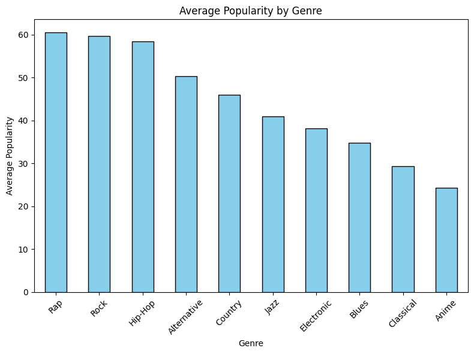

```python
#grouping by genre and getting the average popularity for each
genre_popularity = df_music_genre.groupby('music_genre')['song_popularity'].mean().sort_values(ascending=False)

#plotting
plt.figure(figsize=(8,6))
genre_popularity.plot(kind='bar', color='skyblue', edgecolor='black')


plt.xlabel('Genre')
plt.ylabel('Average Popularity')
plt.title('Average Popularity by Genre')
plt.xticks(rotation=45)
plt.tight_layout()

plt.show()
```

We can see that rap is the most popular genre of music and anime is the least popular. Along with rap, rock and Hip-Hop are also quite popular.

Now that we have this information, we want to see how different musical elements correspond to these genres. This could hint as to what musical elements are causing such popularity.

**Average Musical Element Values for Each Music Genre**

```python
#grouping by genre to see the mean of each numeric attribute
genre_comparison = df_music_genre.groupby('music_genre').mean(numeric_only=True)
genre_comparison
```

| music_genre | instance_id | song_popularity | acousticness | danceability | song_duration_ms | energy | instrumentalness | liveness | loudness | speechiness | tempo | audio_valence |
| --- | --- | --- | --- | --- | --- | --- | --- | --- | --- | --- | --- | --- |
| Alternative | 56028.4330 | 50.2242 | 0.164983 | 0.541124 | 210404.8078 | 0.710880 | 0.060818 | 0.197119 | -6.517714 | 0.088819 | 122.547235 | 0.447513 |
| Anime | 55644.4682 | 24.2716 | 0.286968 | 0.471002 | 208880.8290 | 0.664568 | 0.278057 | 0.193444 | -7.963515 | 0.064608 | 126.799978 | 0.437670 |
| Blues | 55996.8810 | 34.8040 | 0.317830 | 0.529243 | 229301.0962 | 0.609753 | 0.094134 | 0.233206 | -9.009528 | 0.062157 | 121.379962 | 0.580788 |
| Classical | 55630.0076 | 29.3158 | 0.869139 | 0.306560 | 278014.3464 | 0.176534 | 0.600692 | 0.161046 | -21.586253 | 0.051575 | 104.053190 | 0.210523 |
| Country | 56093.5680 | 46.0100 | 0.268827 | 0.577316 | 195556.0686 | 0.638903 | 0.005320 | 0.187781 | -7.297150 | 0.049032 | 123.784286 | 0.536732 |
| Electronic | 56038.9298 | 38.1118 | 0.121971 | 0.619220 | 244553.3832 | 0.738636 | 0.348139 | 0.209782 | -7.034238 | 0.098891 | 125.930571 | 0.389884 |
| Hip-Hop | 56253.0368 | 58.3996 | 0.179093 | 0.717373 | 198395.9458 | 0.644334 | 0.010836 | 0.200870 | -6.851158 | 0.207044 | 120.154134 | 0.474927 |
| Jazz | 55764.8100 | 40.9286 | 0.494564 | 0.584736 | 238092.4468 | 0.474847 | 0.354271 | 0.171721 | -11.185364 | 0.073629 | 111.699415 | 0.509248 |
| Rap | 55408.4536 | 60.4974 | 0.169057 | 0.696605 | 196508.7920 | 0.651301 | 0.009084 | 0.198035 | -6.668337 | 0.186707 | 120.585501 | 0.454999 |
| Rock | 56025.3756 | 59.6412 | 0.191394 | 0.539230 | 212818.3128 | 0.687792 | 0.054656 | 0.185961 | -7.224354 | 0.053403 | 122.669614 | 0.520361 |

Here we can see that popular genres are moreso on the danceable side, offer an energy around 0.6-0.7, and are on the less acoustic side. This information is valuable in seeing what attributes create a popular song, in correspondence to its genre. This is useful to see since our other dataset does not contain a genre category.

**Genre Based Mean Audio Features**

Next, we will narrow down the musical elements and just take a look at the audio features: energy, danceability, and acousticness, to see if there are any relevent or useful correlations. These specific attributes were selected due to having similar ranges.

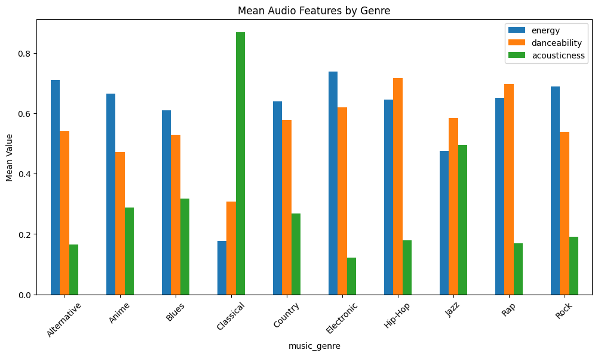

```python
#genre based mean audio features

features = ['energy','danceability','acousticness']

genre_means = df_music_genre.groupby("music_genre")[features].mean()

plt.figure(figsize=(12,6))
genre_means.plot(kind='bar', figsize=(12,6))
plt.title("Mean Audio Features by Genre")
plt.xticks(rotation=45)
plt.ylabel("Mean Value")
plt.show()
```

This data is valuable to loook at when addressing potential predictors for a genre. There are vast differences between particular genres and their audible elements such as Classical having a high acousticness or Electronic having a high level energy.

**Correlation Heatmap for Numeric Musical Elements**

Next, we are going to see how different musical elements are paired together and which pairings appear to be the most popular.

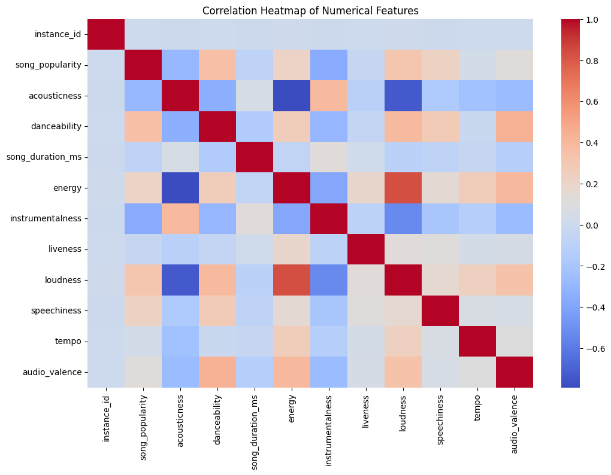

```python
#correlation heatmap for all numeric features
import matplotlib.pyplot as plt
import seaborn as sns


numeric_df = df_music_genre.select_dtypes(include=['float64', 'int64'])

plt.figure(figsize=(12, 8))
sns.heatmap(numeric_df.corr(), annot=False, cmap='coolwarm')
plt.title("Correlation Heatmap of Numerical Features")
plt.show()
```

**Density Plot for Feature Comparisons By Genre**

Next, we are going to look at some density plots to observe how different song elements appear in different genres. This can potentially aid in our genre prediction model.

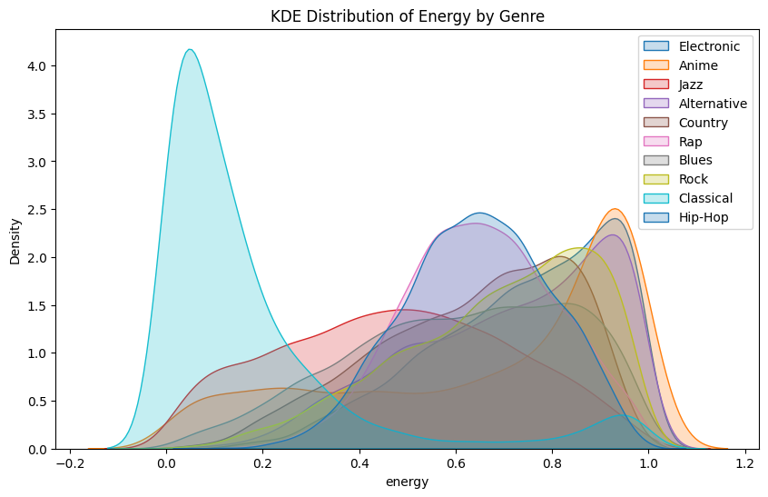

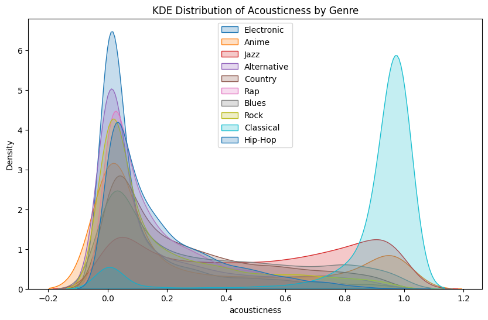

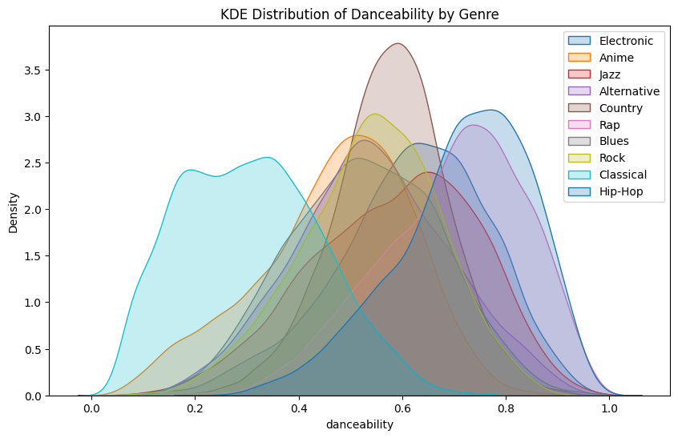

```python
#density plot for feature comparison



for feature in ['energy','acousticness','danceability']:
    plt.figure(figsize=(10,6))
    for genre in df_music_genre['music_genre'].unique():
        sns.kdeplot(
            df_music_genre[df_music_genre['music_genre']==genre][feature],
            label=genre,
            fill=True,
            alpha=0.25
        )
    plt.title(f"KDE Distribution of {feature.capitalize()} by Genre")
    plt.xlabel(feature)
    plt.legend()
    plt.show()
```

This EDA is helpful for us, because density plots show differences in feature shapes, not just averages. So, it helps us to visualize the seperation in genres, for example we can notice that energy for classical music is on the lower side and that Rap and Hip-Hop are almost exactly the same. Additionally, we can see that Classical and Electronic are essentially oppposites in acousticness. Lastly, we can see the large differences between Alternative and Classical genres in terms of danceability.

# **Potential Models for Building**

**Model 1:** Song Popularity Predictor

**Purpose:** Based on our EDA, we could use our findings to build a proper model to predict a song's popularity based on its musical elements.

**Independent Variables:** Different musical elements such as loudness, danceability, genre, song length, or tempo.

**Dependent Variable:** Song Popularity

**Appropriate Test:** K-Nearest Neighbors (KNN)

**Model 2:** Music Genre Classification

**Purpose:** Predict a song's genre using audio features

**Independent Variables:** Audio and musical structure features

**Dependent Variables:** Music Genre

**Appropriate Test:** K-Nearest Neighbors (KNN)

```python
%%shell
jupyter nbconvert --to html "/content/drive/MyDrive/Data_Science_Project.ipynb"
```

[output not shown]

[output cut: 136 more lines]

[output not shown]

[output not shown]